# The Cost of Producing One Additional Vote

Field experiments priced the mobilization tactics campaigns buy, and the price list does not rank the way anyone assumes

Democracy’s Data

Last updated September 13, 2026 at 10:53a EDT

Before the 1998 election, two political scientists divided roughly thirty thousand registered New Haven voters into groups. Some were knocked on, some were telephoned, some were mailed, some were left alone. Afterwards they looked up who had actually turned out in the public voter file, the state’s own list of registered voters, which records whether each person voted and never how; nobody was asked, because the state already knew. Campaigns now spend fortunes on turnout, and that experiment’s descendants put a price on what the money buys. **What does one additional vote actually cost?**

## The test

The test is the field-experiment tradition that New Haven started; a field experiment is one run on real voters in a real election rather than in a laboratory. Gerber and Green (2000) found that door-to-door canvassing, a conversation on the voter’s doorstep, raised turnout substantially, direct mail slightly, and phone calls not at all, and hundreds of randomized experiments followed.[^1] Their design answers a question no filing or return can. Tactics are assigned at random — a coin toss, in effect, decides who is knocked on and who is left alone — so the two groups are alike in every other respect, and the difference in turnout between the treated group and the untreated one, the control group, is an *effect* of the tactic, not an association that something else might explain. The outcome is administrative rather than self-reported: turnout is looked up in the voter file, the record the voter-file chapter describes, so nobody has to be believed.

What this brief reads is the tradition’s own summary. Table 12-1 of Green and Gerber’s *Get Out the Vote*, fifth edition, prints cost and effectiveness for the main tactics.[^2] Three appendices behind it pool 229 experiments — combine their results into one estimate per tactic — with a confidence interval on every pooled estimate, the range within which the true effect plausibly lies given how many people were studied. The compilers ran a large share of those experiments themselves, which is the best available reason to trust the judgment calls inside the table.

## The data

There is no raw file. The numbers exist in a printed book and nowhere else, so every value in `gotv_tactics.csv` was typed in by hand from the cited pages. A transcription fails differently from a download: once, silently, until somebody opens the book again. This file’s audit found exactly that — volunteer phone calls cost $45 per vote in the book, and an earlier version carried $46 for four years.

One row is a *tactic*, a category the compilers invented, averaging over experiments that differed in year, place, electorate and script. The columns are `tactic`, `unit`, `contacts_per_vote`, `cost_per_vote`, the book’s `reliability` sentence, and an `effective` flag; from the appendices come `effect_pp`, the turnout effect in percentage points (the treated group’s turnout rate minus the control group’s), with `ci_low` and `ci_high` bracketing it, and `n_studies`, the number of experiments pooled. Two columns are derived: `cost_per_contact` is `cost_per_vote` over `contacts_per_vote`, and `contacts_per_vote_pooled` is 100 over `effect_pp`. Here is the whole dataset — there is no sample:

| Tactic | Contacts per vote | Cost per vote | The book’s verdict | Measurable effect? |
| --- | --- | --- | --- | --- |
| Door-to-door canvassing | 17 | 57 | Yes, large number of studies | TRUE |
| Leaflets left on doors | 189 | NA | Not significantly greater than zero | FALSE |
| Direct mail, from a campaign | NA | NA | Yes, large number of studies (no detectable effect) | FALSE |
| Direct mail, nonpartisan | 260 | 130 | Yes, large number of studies | TRUE |
| Phone calls, volunteer | 36 | 45 | Yes, large number of studies | TRUE |
| Phone calls, commercial telemarketer | 106 | 106 | Yes, large number of studies | TRUE |
| Robocalls | 425 | 64 | Yes, large number of studies | TRUE |
| Robocalls, excluding social-pressure studies | 699 | 105 | Interval contains zero (not printed in Table 12-1) | FALSE |
| Email | NA | NA | Average effect cannot be large | FALSE |
| Text messages | 381 | 133 | Yes, several large studies | TRUE |
| Election festivals | NA | 85 | Results vary widely across seven studies | FALSE |
| Television GOTV | NA | NA | Not significantly greater than zero | FALSE |
| Radio GOTV | NA | NA | Not significantly greater than zero | FALSE |

And what the appendices supply for the rows they cover:

| Tactic | Effect (pts) | CI low | CI high | Studies |
| --- | --- | --- | --- | --- |
| Door-to-door canvassing | 4.000 | 2.800 | 5.200 | 59 |
| Leaflets left on doors | NA | NA | NA | NA |
| Direct mail, from a campaign | 0.085 | -0.065 | 0.235 | NA |
| Direct mail, nonpartisan | 0.384 | 0.117 | 0.650 | 65 |
| Phone calls, volunteer | 2.780 | 1.740 | 3.830 | 32 |
| Phone calls, commercial telemarketer | 0.940 | 0.520 | 1.360 | 22 |
| Robocalls | 0.235 | 0.037 | 0.433 | 9 |
| Robocalls, excluding social-pressure studies | 0.143 | -0.037 | 0.323 | 7 |
| Email | NA | NA | NA | NA |
| Text messages | 0.260 | NA | NA | NA |
| Election festivals | 1.000 | NA | NA | 7 |
| Television GOTV | 0.500 | NA | NA | NA |
| Radio GOTV | 1.000 | NA | NA | NA |

The intervals deserve their own sentence, because the book publishes them and its own summary table drops them. 17 contacts per vote arrives in Table 12-1 as a bare integer. Seventeen pages later, appendix A gives 59 canvassing experiments and a pooled effect of 4.0 points, with a 95 percent interval of 2.8 to 5.2. The doubt was never unavailable. It was dropped at the summary step, which is where doubt usually goes missing, so this file carries the appendix columns alongside the printed ones.

> **Before you read on, commit to two numbers.** One doorstep conversation is the most persuasive contact anyone has measured. **How many such conversations does it take to produce one additional vote?** And what do you think that vote costs in dollars, bought at the cheapest rate in the table? Write both down.

## What it says about democracy

Read the first row of the table precisely, because almost everyone reads it wrong. One additional vote per 17 conversations does not mean one of the 17 was persuaded to vote; most were going to vote anyway. It means turnout among people spoken to at the door was higher by one vote per 17 **than in an identical group left alone**. The number is a difference between randomized groups, and it exists only because somebody randomized.

Follow the arithmetic once. Suppose 40% of the people left alone turned out to vote. The appendix’s pooled estimate for canvassing is 4.0 percentage points, so among the people spoken to at the door, turnout was 44.0%. Subtract, and there are 4.0 extra voters for every hundred people contacted, which is one extra vote for every 25 conversations — the figure the file’s `contacts_per_vote_pooled` column carries. Table 12-1 prints 17 instead. The printed summary and the appendix behind it do not agree, and the file carries both so that the gap stays visible.

Now give the table a budget of $250,000 and let it spend:

| If you spent the whole budget on… | Additional votes |
| --- | --- |
| Phone calls, volunteer | 5,555 |
| Door-to-door canvassing | 4,385 |
| Robocalls | 3,906 |
| Phone calls, commercial telemarketer | 2,358 |
| Direct mail, nonpartisan | 1,923 |
| Text messages | 1,879 |

**The best choice buys about 5,555 additional votes and the worst effective tactic buys 1,879** — a factor of 3.0 between the best and worst use of the same money. Which tactic is “best” depends entirely on which column you rank:

Left to middle, every line crosses every other: the rank correlation between effectiveness and cost per conversation is exactly -1. Middle to right, the order scrambles again.

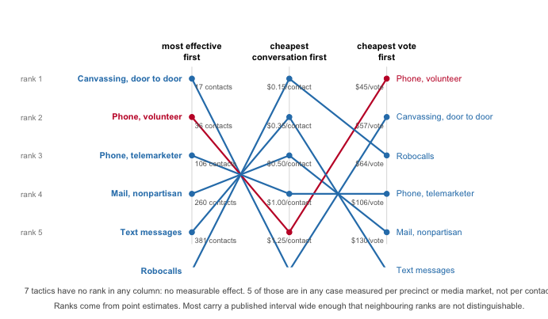

**Figure 1. The same 6 tactics, ranked three ways, and no two orders agree.** A slope chart fits this question because the finding *is* the crossing of the lines: between the first two columns every line crosses every other, a rank correlation — a measure of whether two orderings agree, +1 when they are identical and −1 when one is the other reversed — of exactly -1. The most persuasive contact is reliably the most expensive one to obtain, and the third column, cost per vote, is the one a campaign actually spends against.

The blank cells are a finding of their own:

| Tactic | Cost per vote | Point estimate | 95% CI |
| --- | --- | --- | --- |
| Leaflets left on doors | — | not measured | — |
| Direct mail, from a campaign | — | 0.085 pts | -0.065 to 0.235 |
| Robocalls, excluding social-pressure studies | $105 | 0.143 pts | -0.037 to 0.323 |
| Email | — | not measured | — |
| Election festivals | $85 | 1.000 pts | — |
| Television GOTV | — | 0.500 pts | — |
| Radio GOTV | — | 1.000 pts | — |

**7 of 13 tactics have no measurable turnout effect, and most of what arrives in an October mailbox is on the list.** Look at the last two columns, though: these are not missing data. The experiments were run, and they produced small positive estimates whose intervals include zero: the true effect could be nothing at all or slightly positive, and the experiments cannot say which. Mail from a campaign is 0.085 points with an interval from -0.065 to 0.235, which is a much more specific statement than “it does not work.” A student who dropped the incomplete rows would delete exactly the findings most likely to change how a campaign spends.

One row shows the source contradicting itself, which matters because a compilation has no custodian to ask:

| Estimate | Effect (pts) | 95% CI | Contacts per vote | Cost per vote |
| --- | --- | --- | --- | --- |
| all nine studies | 0.235 | 0.037 to 0.433 | 425 | $64 |
| excluding the two social-pressure studies | 0.143 | -0.037 to 0.323 | 699 | $105 |

And the cheapest rate in the table is not a price at all. The $45 volunteer-phone figure prices the phones and the list; the labor is volunteers, and **you cannot buy a volunteer**. Model it instead as a capacity: so many volunteer hours, at 16 conversations an hour, with the rest of the budget spent on canvassing. The advertised rate becomes a ceiling:

The blue band is money doing the work the volunteers could not. It is thickest when there are no volunteers and disappears exactly where the campaign finally has enough of them.

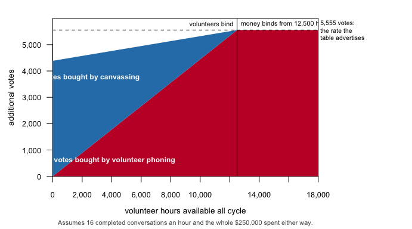

**Figure 2. The advertised rate is a ceiling almost nobody reaches.** An area chart over every possible volunteer supply, because the finding is a gap between two bands. Red is votes from volunteer phoning; blue is money doing the work the volunteers could not, at canvassing prices. The bands only reach the dashed line, 5,555 votes at the table’s cheapest rate, at 12,500 volunteer hours — where the binding constraint stops being people and starts being money.

Below that crossover, which is where essentially every real campaign sits, fifty more volunteers are worth more than fifty thousand more dollars. And the ranking is fragile in one assumption the file does not record: value a volunteer’s hour at anything above about $5.33, and canvassing becomes the cheaper way to buy a vote. The assumptions that make a number meaningful are almost never stored in the same place as the number.

## What this brief cannot tell you

**What a vote would cost your campaign, this year, in your state.** The rows carry no dates, no places and no dollar-year; wages, postage and phone charges have all moved since the experiments ran.

**Whether the compilation is complete.** A literature has no sampling frame — no list of every experiment ever run, against which the compilers could check what they missed — and this one has measured publication bias in itself, the tendency for studies that find nothing to go unpublished. Gerber, Green and Nickerson (2001) showed that published mobilization effects shrink as sample size grows, the signature of missing null results.[^4] The appendices reach for unpublished work deliberately, but the reach cannot be audited from inside the file.

**Whether any of this persuades.** Every number is a turnout effect. Kalla and Broockman (2018), pooling 49 field experiments, put the average persuasive effect of campaign contact in general elections near zero.[^5] So the blank-cell tactics may still be rational purchases for fundraising or list-building, just not for turnout.

**Whether trial effects survive at industrial scale.** Enos and Fowler (2018) estimate that the full weight of two presidential campaigns raised turnout 7 to 8 points where it was concentrated.[^6] Whether that is this table multiplied up, or saturation and media, is open.

## What you should have learned

- A mobilization effect is a difference between randomized groups: one vote per 17 doorstep conversations means turnout ran that much higher than in an identical group left alone.
- Effectiveness and cost rank the tactics in reverse: the rank correlation between contacts-per-vote and cost-per-contact across the 6 priceable tactics is -1.
- The same $250,000 buys 5,555 votes at the cheapest rate and 1,879 at the dearest effective one, a factor of 3.0.
- The cheapest rate is a capacity, not a price: below about 12,500 volunteer hours the $45 figure is unreachable, and above a wage of $5.33 an hour it is not the cheapest at all.
- 7 of 13 tactics show no measurable effect, and those cells are results with confidence intervals, not missing data.

## Extensions

None of these is answered above, and every one can be answered from the table the Sources section hands over.

- `gotv_tactics.csv` has both `cost_per_vote` and `n_studies`. Sort by each. Do the cheapest tactics have the most evidence behind them, or the least?
- `ci_low` and `ci_high` bracket the pooled estimates. Which tactics have an interval that includes zero, and which of those are still sold as though they work?
- `contacts_per_vote` says how many contacts buy one extra vote. Pick a tactic and work out what a campaign with $50,000 could buy.
- Compare `contacts_per_vote` against `contacts_per_vote_pooled`, the figure the appendix implies. For which tactics does the printed table flatter the tactic?

One stretch idea points past the spreadsheet: reprice one row yourself. Find current postage or commercial phone-bank rates, rebuild `cost_per_vote` for that tactic, and see whether its rank in Figure 1’s third column survives.

## Sources

**Data**

- Green, D. P. and Gerber, A. S. (2024). *Get Out the Vote: How to Increase Voter Turnout*, 5th ed. Brookings Institution Press, ISBN 978-0-8157-4062-9; the publisher’s page is https://www.brookings.edu/books/get-out-the-vote/. These numbers are in a printed book and nowhere else; there is no file to download, which is why everything in `gotv_tactics.csv` was typed in by hand. Specifically: **Table 12-1, pp. 172–73** (the tactics, effectiveness, reliability wording and cost per vote, with footnote b defining a “contact” per row); **Appendix A, pp. 189–93** (59 canvassing experiments and pooled intervals); **Appendix B, pp. 195–99** (130 mail experiments); **Appendix C, pp. 201–04** (phone experiments, including both robocall estimates).

**Academic literature**

- Enos, R. D. and Fowler, A. (2018). “Aggregate Effects of Large-Scale Campaigns on Voter Turnout.” *Political Science Research and Methods* 6(4): 733–751. https://doi.org/10.1017/psrm.2016.21
- Gerber, A. S. and Green, D. P. (2000). “The Effects of Canvassing, Telephone Calls, and Direct Mail on Voter Turnout: A Field Experiment.” *American Political Science Review* 94(3): 653–663. https://doi.org/10.2307/2585837
- Gerber, A. S., Green, D. P. and Nickerson, D. (2001). “Testing for Publication Bias in Political Science.” *Political Analysis* 9(4): 385–392. https://doi.org/10.1093/oxfordjournals.pan.a004877
- Kalla, J. L. and Broockman, D. E. (2018). “The Minimal Persuasive Effects of Campaign Contact in General Elections: Evidence from 49 Field Experiments.” *American Political Science Review* 112(1): 148–166. https://doi.org/10.1017/S0003055417000363
- Gerber, A. S., Green, D. P. and Larimer, C. W. (2008). “Social Pressure and Voter Turnout: Evidence from a Large-Scale Field Experiment.” *American Political Science Review* 102(1): 33–48. https://doi.org/10.1017/S000305540808009X

**The data itself**

Every figure above is drawn from this table. It is plain CSV, it opens in a spreadsheet, and it is yours to take further.

`gotv_tactics.csv`

Why this data cannot be fetched again

```
The numbers behind this chapter come from a source you cannot download,
because there is nothing to download: the source is a printed book.

WHY NOT. The chapter is built on Donald P. Green and Alan S. Gerber,
"Get Out the Vote: How to Increase Voter Turnout", 5th edition
(Brookings Institution Press, 2024) — specifically Table 12-1 on
pages 172-73, the book's price list of what one additional vote costs
under each mobilization tactic, and appendices A, B, and C, which
carry the pooled effects, confidence intervals, and study counts
behind it. Those pages were keyed in by hand. The book has no
companion dataset, no download page, and no API, and no assistant can
download a page of a printed book for you.

WHAT EXISTS INSTEAD. The book itself — a library, a bookstore, or the
publisher. With a copy open to Table 12-1 you can re-key the table in
an afternoon, and the appendices supply the confidence intervals the
printed table leaves out.

WHAT YOU CAN STILL CHECK. If you key the table yourself, these
numbers say whether you are reading the same edition:
- twelve tactics in Table 12-1, door-to-door canvassing through
  radio; the version here carries thirteen rows, because the
  robocall estimate is recorded twice — with and without the two
  social-pressure studies the book's own caption disclaims
- door-to-door canvassing: one additional vote per 17 conversations
- robocalls: one vote per 425 numbers targeted; nonpartisan direct
  mail: one per 260 mailers sent; text messages: one per 381
A 6th edition would re-pool the experiments and move every number;
that would be a new book, not an error in your copy.
```

[^1]: Alan S. Gerber and Donald P. Green, “The Effects of Canvassing, Telephone Calls, and Direct Mail on Voter Turnout: A Field Experiment,” *American Political Science Review* 94, no. 3 (2000): 653–663, https://doi.org/10.2307/2585837.
[^2]: Donald P. Green and Alan S. Gerber, *Get Out the Vote: How to Increase Voter Turnout*, 5th ed. (Brookings Institution Press, 2024), https://www.brookings.edu/books/get-out-the-vote/.
[^3]: The tactic’s founding experiment used mail rather than the telephone: Alan S. Gerber, Donald P. Green and Christopher W. Larimer, “Social Pressure and Voter Turnout: Evidence from a Large-Scale Field Experiment,” *American Political Science Review* 102, no. 1 (2008): 33–48, https://doi.org/10.1017/S000305540808009X.
[^4]: Alan S. Gerber, Donald P. Green and David Nickerson, “Testing for Publication Bias in Political Science,” *Political Analysis* 9, no. 4 (2001): 385–392, https://doi.org/10.1093/oxfordjournals.pan.a004877.
[^5]: Joshua L. Kalla and David E. Broockman, “The Minimal Persuasive Effects of Campaign Contact in General Elections: Evidence from 49 Field Experiments,” *American Political Science Review* 112, no. 1 (2018): 148–166, https://doi.org/10.1017/S0003055417000363.
[^6]: Ryan D. Enos and Anthony Fowler, “Aggregate Effects of Large-Scale Campaigns on Voter Turnout,” *Political Science Research and Methods* 6, no. 4 (2018): 733–751, https://doi.org/10.1017/psrm.2016.21.